# 🏎️ Formula 1: Drive to Survive – Report

## 🏁 Overview

*Formula 1: Drive to Survive* is a British documentary series produced by Netflix in collaboration with Formula One. The series provides a behind-the-scenes look into the world of Formula 1 racing, including the lives of drivers, the dynamics within teams, and the drama of the racing season.

*First released in 2019, the show has aired seven seasons as of March 7, 2025.*

**It has played a significant role in boosting global interest in Formula 1.**

A crossover event with **Full Swing** broadcast on Netflix in November 2023 called *The Netflix Cup*.

## 🖼️ Logo

[figure not shown]

## 📊 Basic Statistics

| Series | Episodes | Originally Released |
| --- | --- | --- |
| 1 | 10 | 8 March 2019 |
| 2 | 10 | 28 February 2020 |
| 3 | 10 | 19 March 2021 |
| 4 | 10 | 11 March 2022 |
| 5 | 10 | 24 February 2023 |
| 6 | 10 | 23 February 2024 |
| 7 | 10 | 7 March 2025 |

## 📈 Viewership Graph

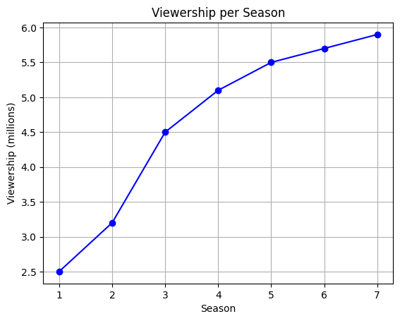

```python
import matplotlib.pyplot as plt

seasons = [1, 2, 3, 4, 5, 6, 7]
viewers = [2.5, 3.2, 4.5, 5.1, 5.5, 5.7, 5.9]

plt.plot(seasons, viewers, marker='o', color='blue')
plt.title('Viewership per Season')
plt.xlabel('Season')
plt.ylabel('Viewership (millions)')
plt.grid(True)
plt.show()
```

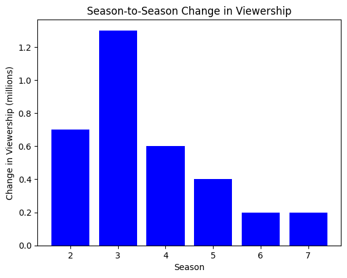

```python
import numpy as np

changes = np.diff(viewers)

plt.bar(seasons[1:], changes, color='blue')
plt.title('Season-to-Season Change in Viewership')
plt.xlabel('Season')
plt.ylabel('Change in Viewership (millions)')
plt.axhline(0, color='black', linewidth=0.8)
plt.show()
```

## 🧾 Observations

- The largest increase in viewership occurred between Seasons 2 and 3.
- After this peak, the growth in viewership from season to season has slowed down.
- This suggests that the series may have reached its prime audience, and future growth in viewership could be limited.

## 📚 References

- [Formula 1: Drive to Survive – Wikipedia](https://en.wikipedia.org/wiki/Formula_1:_Drive_to_Survive)
- The numbers of viewers are artificial. 🤫